# Clase 01

```
Instalación, ayuda, búsquedas:
R, CRAN, R-seek, RStudio, install.packages, library
Variables y tipos, importar datos:
vectores, matrices, factores, list, asignación
dataframe, tibles
```

Una versión actualizada de este material en : [clase01](https://mar71n.github.io/rconr/clase01.html)

## Instalar:

### Página principal de R:

- https://www.r-project.org/
- Descargas o CRAN lleva a : https://cran.r-project.org/mirrors.html
- Donde vemos una lista de “mirrors”.
- De Argentina : El de la [Facultad de Ciencias Astronómicas y Geofísicas - UNLP](https://www.fcaglp.unlp.edu.ar/)

http://mirror.fcaglp.unlp.edu.ar/CRAN/

- O uno general https://cloud.r-project.org/ que de alguna manera elije entre los disponibles.

Descargamos el instalador para el SO y arquitectura correspondiente.

En caso de tener una versión anterior instalada, lo mejor es desinstalarla. Ver: Upgrade en CRAN

En redes que usan un proxy para conectarse a internet: configurar proxy

### Rtools :

Para algunas instalaciones de paquetes en Windows

- para R4.2: https://cran.r-project.org/bin/windows/Rtools/rtools42/rtools.html
- para R3.6 o menos : https://cran.r-project.org/bin/windows/Rtools/history.html

### Rstudio :

- [www.rstudio.com](https://www.rstudio.com/)
- www.rstudio.com/products/rstudio/download/

#### RStudio se convierte en **Posit** en Octubre. [**posit.co**](https://posit.co/)

### Búsquedas y ayuda :

- https://rseek.org/
- https://www.rdocumentation.org/
- https://community.rstudio.com/
- [versión en español de Stack Overflow](https://es.stackoverflow.com/)

### Paquetes:

#### Librería estándar :

##### Estos paquetes se instalan junto con R. Por lo que no hace falta instalarlos con *install.packages()*

##### [*Paquetes de la librería estándar*](https://stat.ethz.ch/R-manual/R-devel/doc/html/packages.html)

##### Algunos de ellos se cargan al comenzar, por lo que tampoco hace falta cargarlos con *library()*

- [base](https://stat.ethz.ch/R-manual/R-devel/library/base/html/00Index.html)
- [stats](https://stat.ethz.ch/R-manual/R-devel/library/stats/html/00Index.html)
- [utils](https://stat.ethz.ch/R-manual/R-devel/library/utils/html/00Index.html)
- [datasets](https://stat.ethz.ch/R-manual/R-devel/library/datasets/html/00Index.html)
- …

#### Tidyverse :

- [www.tidyverse.org](https://www.tidyverse.org/packages/)
  - [**dplyr**](https://dplyr.tidyverse.org/)
  - [**ggplot2**](https://ggplot2.tidyverse.org/)
  - [**readr**](https://readr.tidyverse.org/)
  - [**lubridate**](https://lubridate.tidyverse.org/)
  - [**stringr**](https://stringr.tidyverse.org/)

#### sf :

- r-spatial.github.io/sf/

## Variables y tipos, importar algunos datos:

#### Con la función *typeof(x)* vemos el *type* al que pertenece x

##### Ejemplos de los principales tipos en R:

```r
typeof(1.2)
```

```
## [1] "double"
```

```r
typeof(1L)
```

```
## [1] "integer"
```

```r
typeof("abc")
```

```
## [1] "character"
```

```r
typeof(TRUE)
```

```
## [1] "logical"
```

```r
typeof(2+1i)
```

```
## [1] "complex"
```

#### Con los tipos numéricos, R es una “calculadora”

```r
# Suma
15 + 35
```

```
## [1] 50
```

```r
# Resta
50 - 35
```

```
## [1] 15
```

```r
# Multiplicación
3 * 5
```

```
## [1] 15
```

```r
# Division
(15 + 35) / 2
```

```
## [1] 25
```

```r
# Potencia
2^8
```

```
## [1] 256
```

```r
# Division
29 / 6
```

```
## [1] 4.833333
```

```r
# Division entera
29 %/% 6
```

```
## [1] 4
```

```r
# Modulo o resto
29 %% 6
```

```
## [1] 5
```

#### Con **?**item nos muestra ayuda sobre el *item*

##### Los ejemplos siguientes nos muestran en el panel de *Help* las funciones matemáticas disponibles con la librería estándar.

```r
?Arithmetic # Operadores aritméticos

# x + y
# x - y
# x * y
# x / y
# x ^ y
# x %% y
# x %/% y

?log  # logaritmo y exponenciacón

# log(x, base = exp(1))
# logb(x, base = exp(1))
# log10(x)
# log2(x)
# exp(x)

?sin  # trigonometricas

# cos(x)
# sin(x)
# tan(x)

# acos(x)
# asin(x)
# atan(x)

?Special  # factorial

# factorial(x)
# lfactorial(x)

?sqrt  # raiz cuadrada

# abs(x)
# sqrt(x)
```

#### Podemos graficar una función

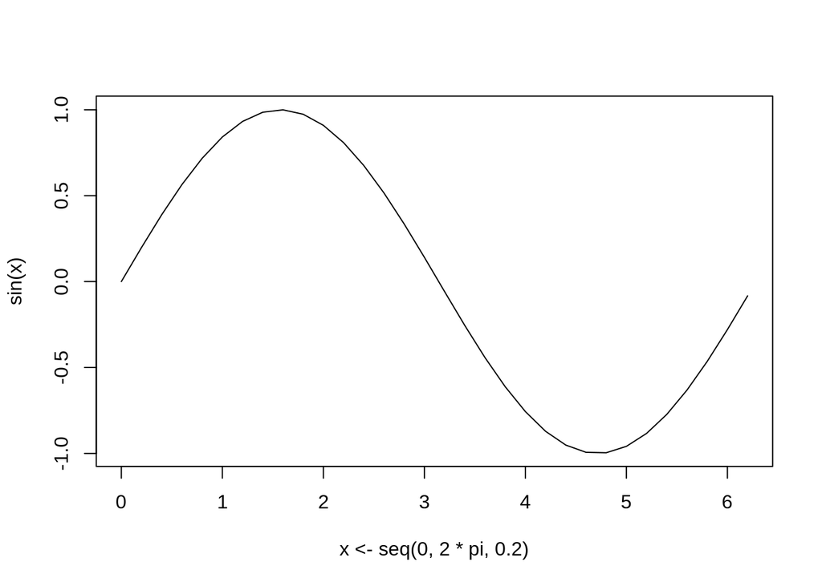

```r
plot(x <- seq(0, 2*pi, 0.2), sin(x), type = "l")
```

#### Puedo usar variables :

```r
precio_anterior = 85.23
precio_actual = 99.0
diferencia = precio_actual - precio_anterior
# La suma y la resta son peligrosas, porque cuando hay involucrados números de diferentes órdenes de magnitud, los dígitos del más pequeño se pierden
# Que % aumento ? (del precio inicial)
diferencia / precio_anterior * 100
```

```
## [1] 16.15628
```

```r
((precio_actual / precio_anterior) - 1) * 100
```

```
## [1] 16.15628
```

#### Lo puedo poner en una funcion :

```r
# esta es la definición de la función
aumento <- function(x, y){
  ((y / x) - 1) * 100
}

# acá llamo a la función y obtengo el resultado
aumento(precio_anterior, precio_actual)
```

```
## [1] 16.15628
```

## Vectores

#### Los vectores solo pueden contener valores de un mismo tipo. Todos numericos, o todos caracteres, etc.

```r
c(1, 4, 7, 3)
```

```
## [1] 1 4 7 3
```

```r
c("a", "23", "abc")
```

```
## [1] "a"   "23"  "abc"
```

```r
c(TRUE, FALSE, FALSE, TRUE)
```

```
## [1]  TRUE FALSE FALSE  TRUE
```

```r
vnumeros <- c(1500, 4750, 7300, 3250, 4701, 3302, 5200)
```

#### Podemos extraer el valor almacenado indicando la posición o índice:

#### con [*[*](https://www.rdocumentation.org/packages/base/versions/3.6.2/topics/Extract)

```r
# el segundo elemento:
vnumeros[2]
```

```
## [1] 4750
```

```r
# el segundo y el quinto elementos:
vnumeros[c(2,5)]
```

```
## [1] 4750 4701
```

```r
# del quinto al septimo elementos:
vnumeros[5:7]
```

```
## [1] 4701 3302 5200
```

#### Tambien pordemos extraer los valores que cumplan alguna condición:

#### La función [base::*which*](https://www.rdocumentation.org/packages/base/versions/3.6.2/topics/which) nos responde qué índices son verdaderos.

```r
# Al vectorizar, R evalúa la comparación elemento por elemento
# vector booleano con TRUE donde el elemento es mayor que 4000, y FALSE en caso contrario.
vnumeros > 4000
```

```
## [1] FALSE  TRUE  TRUE FALSE  TRUE FALSE  TRUE
```

```r
# elementos que cumplen la condición
vnumeros[vnumeros > 4000]
```

```
## [1] 4750 7300 4701 5200
```

```r
# índices de los elementos que cumplen la condición
which(vnumeros > 4000)
```

```
## [1] 2 3 5 7
```

```r
vnumeros[which(vnumeros > 4000)]
```

```
## [1] 4750 7300 4701 5200
```

```r
# índice del menor elemento seguido del índice del segundo valor, y así..
order(vnumeros)
```

```
## [1] 1 4 6 5 2 7 3
```

```r
# elementos ordenados
vnumeros[order(vnumeros)]
```

```
## [1] 1500 3250 3302 4701 4750 5200 7300
```

```r
# elementos ordenados
sort(vnumeros)
```

```
## [1] 1500 3250 3302 4701 4750 5200 7300
```

#### Puedo hacer operaciones con los vectores, o pasarlos como argumento de funciones que así lo admitan:

```r
precios_enero <- c(100, 600, 20000, 45)
precios_marzo <- c(110, 650, 21000, 45)

# la función *sum(x)* devuelve la suma de los valores almacenados en x
total_enero <- sum(precios_enero)
total_marzo <- sum(precios_marzo)

aumento(total_enero, total_marzo)
```

```
## [1] 5.109665
```

```r
precios_marzo - precios_enero
```

```
## [1]   10   50 1000    0
```

```r
aumento(precios_enero, precios_marzo)
```

```
## [1] 10.000000  8.333333  5.000000  0.000000
```

#### Hay disponibles muchas funciones

```r
max(precios_enero)
```

```
## [1] 20000
```

```r
min(precios_enero)
```

```
## [1] 45
```

```r
length(precios_enero)
```

```
## [1] 4
```

```r
mean(precios_enero)
```

```
## [1] 5186.25
```

### Matrices

#### Las matrices, igual que los vectores, solo pueden contener valores de un mismo tipo. Todos numericos, o todos caracteres, etc.

```r
matriz <- matrix(c(18, 8.10, 20, 9, 21, 9.45, 22,   9.90, 23,   10.35), ncol = 2, byrow = TRUE )

matriz
```

```
##      [,1]  [,2]
## [1,]   18  8.10
## [2,]   20  9.00
## [3,]   21  9.45
## [4,]   22  9.90
## [5,]   23 10.35
```

```r
# La columna 1
matriz[,1]
```

```
## [1] 18 20 21 22 23
```

```r
# La fila 3
matriz[3,]
```

```
## [1] 21.00  9.45
```

```r
# El elemeneto guardado en la fila 3, columna 1
matriz[3,1]
```

```
## [1] 21
```

```r
# Las filas desde la 2 a la 4
matriz[2:4,]
```

```
##      [,1] [,2]
## [1,]   20 9.00
## [2,]   21 9.45
## [3,]   22 9.90
```

#### Puedo ponerle nombre a las dimensiones de una matriz:

```r
# https://www.argentina.gob.ar/redsube/tarifas-de-transporte-publico-amba-2021

matriz_colectivo <- matrix(
  filas <- c(18, 8.10, 20, 9, 21,   9.45, 22,   9.90, 23,   10.35),
  nrow = 5, byrow = TRUE,
  dimnames = list(c("0 a 3 km", "3 a 6 km", "6 a 12 km", "12 a 27 km", "más de 27 km"),
                  c("Tarifa"    ,"Con tarifa social"))
)

matriz_colectivo
```

```
##              Tarifa Con tarifa social
## 0 a 3 km         18              8.10
## 3 a 6 km         20              9.00
## 6 a 12 km        21              9.45
## 12 a 27 km       22              9.90
## más de 27 km     23             10.35
```

#### Puedo hacer operaciones, por ejemplo multiplicar por un escalar:

##### En este ejemplo estaría calculando un incremento de 40% sobre toda la matriz

```r
matriz_colectivo * 1.4
```

```
##              Tarifa Con tarifa social
## 0 a 3 km       25.2             11.34
## 3 a 6 km       28.0             12.60
## 6 a 12 km      29.4             13.23
## 12 a 27 km     30.8             13.86
## más de 27 km   32.2             14.49
```

#### Puedo invocar una dimensión, en este caso una columna, por su nombre:

```r
matriz_colectivo[,"Tarifa"] * 1.4
```

```
##     0 a 3 km     3 a 6 km    6 a 12 km   12 a 27 km más de 27 km
##         25.2         28.0         29.4         30.8         32.2
```

### También podemos multiplicarla por otra matriz, elemento a elemento

```r
aumentos <- matrix(c(rep(1.4,5), rep(1,5)), nrow = 5, byrow = FALSE)

aumentos
```

```
##      [,1] [,2]
## [1,]  1.4    1
## [2,]  1.4    1
## [3,]  1.4    1
## [4,]  1.4    1
## [5,]  1.4    1
```

```r
matriz_colectivo * aumentos
```

```
##              Tarifa Con tarifa social
## 0 a 3 km       25.2              8.10
## 3 a 6 km       28.0              9.00
## 6 a 12 km      29.4              9.45
## 12 a 27 km     30.8              9.90
## más de 27 km   32.2             10.35
```

#### Ordenar la matriz según alguna de sus dimensiones

```r
decreciente <- order(matriz_colectivo[,1], decreasing = TRUE)
matriz_colectivo[decreciente, ]
```

```
##              Tarifa Con tarifa social
## más de 27 km     23             10.35
## 12 a 27 km       22              9.90
## 6 a 12 km        21              9.45
## 3 a 6 km         20              9.00
## 0 a 3 km         18              8.10
```

### Listas

#### Las listas sí pueden almacenar objetos de distintos tipos.

```r
l1 <- list(1,2,3,c(4,5,6), "A", c("B","C"), list(c(1,2,3), c("a","b", "c")))
l1
```

```
## [[1]]
## [1] 1
##
## [[2]]
## [1] 2
##
## [[3]]
## [1] 3
##
## [[4]]
## [1] 4 5 6
##
## [[5]]
## [1] "A"
##
## [[6]]
## [1] "B" "C"
##
## [[7]]
## [[7]][[1]]
## [1] 1 2 3
##
## [[7]][[2]]
## [1] "a" "b" "c"
```

```r
length(l1)
```

```
## [1] 7
```

```r
# Así le agrego un elemento a la lista:
l1[[8]] <- c("c", "b", "a")

l1[1]
```

```
## [[1]]
## [1] 1
```

```r
l1[[1]]
```

```
## [1] 1
```

```r
l1[4]
```

```
## [[1]]
## [1] 4 5 6
```

```r
l1[[4]]
```

```
## [1] 4 5 6
```

```r
l1[[4]][2]
```

```
## [1] 5
```

```r
l1[[7]][[2]]
```

```
## [1] "a" "b" "c"
```

```r
l1[[7]][[2]][1]
```

```
## [1] "a"
```

```r
lt <- list(t = matriz_colectivo[,1], ts = matriz_colectivo[,2])

sapply(lt, mean)
```

```
##     t    ts
## 20.80  9.36
```

### Algunos datasets

[Buenos Aires Data - Barrios](https://data.buenosaires.gob.ar/dataset/barrios)

[Buenos Aires Data - Comunas](https://data.buenosaires.gob.ar/dataset/comunas)

#### data.frame

```r
# barrios <- read.csv("https://cdn.buenosaires.gob.ar/datosabiertos/datasets/barrios/barrios.csv", encoding = "UTF-8")
# download.file("https://cdn.buenosaires.gob.ar/datosabiertos/datasets/barrios/barrios.csv", "datos/barrios.csv")
barrios <- read.csv("datos/barrios.csv", encoding = "UTF-8")

# poblacion <- read.csv("https://cdn.buenosaires.gob.ar/datosabiertos/datasets/barrios/caba_pob_barrios_2010.csv", encoding = "UTF-8")
# download.file("https://cdn.buenosaires.gob.ar/datosabiertos/datasets/barrios/caba_pob_barrios_2010.csv", "datos/caba_pob_barrios_2010.csv")
poblacion <- read.csv("datos/caba_pob_barrios_2010.csv", encoding = "UTF-8")

# comunas <- read.csv("https://cdn.buenosaires.gob.ar/datosabiertos/datasets/comunas/comunas.csv", encoding = "UTF-8")
# download.file("https://cdn.buenosaires.gob.ar/datosabiertos/datasets/comunas/comunas.csv", "datos/comunas.csv")
comunas <- read.csv("datos/comunas.csv", encoding = "UTF-8")

names(barrios)
```

```
## [1] "WKT"       "barrio"    "comuna"    "perimetro" "area"
```

```r
str(barrios)
```

```
## 'data.frame':    48 obs. of  5 variables:
##  $ WKT      : chr  "POLYGON ((-58.4528200492791 -34.5959886570639,-58.453655193137 -34.5965557163041,-58.4537674321647 -34.59663424"| __truncated__ "POLYGON ((-58.4655768128541 -34.5965577078058,-58.4656201094845 -34.5967043067336,-58.4655402165487 -34.5966463"| __truncated__ "POLYGON ((-58.42375…
##  $ barrio   : chr  "CHACARITA" "PATERNAL" "VILLA CRESPO" "VILLA DEL PARQUE" ...
##  $ comuna   : int  15 15 15 11 5 6 11 10 10 7 ...
##  $ perimetro: num  7725 7088 8132 7705 8538 ...
##  $ area     : num  3115707 2229829 3615978 3399596 4050752 ...
```

```r
summary(barrios)
```

```
##      WKT               barrio              comuna         perimetro
##  Length:48          Length:48          Min.   : 1.000   Min.   : 4531
##  Class :character   Class :character   1st Qu.: 4.000   1st Qu.: 6554
##  Mode  :character   Mode  :character   Median : 9.500   Median : 8254
##                                        Mean   : 8.458   Mean   : 9863
##                                        3rd Qu.:12.000   3rd Qu.:11127
##                                        Max.   :15.000   Max.   :22127
##       area
##  Min.   : 1232270
##  1st Qu.: 2222027
##  Median : 3679709
##  Mean   : 4242703
##  3rd Qu.: 5142993
##  Max.   :15845871
```

#### Usamos *%>%* y *select()* del paquete [*dplyr*](https://dplyr.tidyverse.org/)

##### [%>%](https://magrittr.tidyverse.org/reference/pipe.html)

###### **Estaremos usando paquetes que integran *tidyverse* y que se instalan al instalar este último.**

###### **Pero recomiendo ir instalando a medida que los usemos.**

```r
# install.packages("dplyr")

library(dplyr)
names(barrios)
```

```
## [1] "WKT"       "barrio"    "comuna"    "perimetro" "area"
```

#### [dplyr::select](https://dplyr.tidyverse.org/reference/select.html)

```r
select(barrios, barrio, comuna)
```

```
##               barrio comuna
## 1          CHACARITA     15
## 2           PATERNAL     15
## 3       VILLA CRESPO     15
## 4   VILLA DEL PARQUE     11
## 5            ALMAGRO      5
## 6          CABALLITO      6
## 7   VILLA SANTA RITA     11
## 8       MONTE CASTRO     10
## 9         VILLA REAL     10
## 10            FLORES      7
## 11          FLORESTA     10
## 12      CONSTITUCION      1
## 13     SAN CRISTOBAL      3
## 14             BOEDO      5
```

[output cut: 34 more lines]

```r
barrios %>% select(barrio, comuna)
```

```
##               barrio comuna
## 1          CHACARITA     15
## 2           PATERNAL     15
## 3       VILLA CRESPO     15
## 4   VILLA DEL PARQUE     11
## 5            ALMAGRO      5
## 6          CABALLITO      6
## 7   VILLA SANTA RITA     11
## 8       MONTE CASTRO     10
## 9         VILLA REAL     10
## 10            FLORES      7
## 11          FLORESTA     10
## 12      CONSTITUCION      1
## 13     SAN CRISTOBAL      3
## 14             BOEDO      5
```

[output cut: 34 more lines]

```r
barrios %>% select(!WKT)
```

```
##               barrio comuna perimetro     area
## 1          CHACARITA     15  7724.853  3115707
## 2           PATERNAL     15  7087.513  2229829
## 3       VILLA CRESPO     15  8131.857  3615978
## 4   VILLA DEL PARQUE     11  7705.390  3399596
## 5            ALMAGRO      5  8537.901  4050752
## 6          CABALLITO      6 10990.964  6851029
## 7   VILLA SANTA RITA     11  5757.752  2153691
## 8       MONTE CASTRO     10  7361.036  2627481
## 9         VILLA REAL     10  5070.966  1334146
## 10            FLORES      7 15772.440  8590784
## 11          FLORESTA     10  7519.654  2320641
## 12      CONSTITUCION      1  6326.841  2101995
## 13     SAN CRISTOBAL      3  5987.226  2043711
## 14             BOEDO      5  6602.510  2609851
```

[output cut: 34 more lines]

#### De la librería estándar, podemos usar

[*$*](https://stat.ethz.ch/R-manual/R-devel/library/base/html/Extract.html) ó [*[*](https://www.rdocumentation.org/packages/base/versions/3.6.2/topics/Extract) para seleccionar columnas

```r
# head() nos muestra los primeros elementos de un objeto

head(
  barrios$area
)
```

```
## [1] 3115707 2229829 3615978 3399596 4050752 6851029
```

```r
head(
  barrios[c("barrio", "comuna")]
)
```

```
##             barrio comuna
## 1        CHACARITA     15
## 2         PATERNAL     15
## 3     VILLA CRESPO     15
## 4 VILLA DEL PARQUE     11
## 5          ALMAGRO      5
## 6        CABALLITO      6
```

```r
# con el %>% resulta más claro

barrios[c("barrio", "comuna")] %>% head
```

```
##             barrio comuna
## 1        CHACARITA     15
## 2         PATERNAL     15
## 3     VILLA CRESPO     15
## 4 VILLA DEL PARQUE     11
## 5          ALMAGRO      5
## 6        CABALLITO      6
```

```r
barrios[c(2,3)] %>% head
```

```
##             barrio comuna
## 1        CHACARITA     15
## 2         PATERNAL     15
## 3     VILLA CRESPO     15
## 4 VILLA DEL PARQUE     11
## 5          ALMAGRO      5
## 6        CABALLITO      6
```

```r
barrios[c(-1,-4,-5)] %>% head
```

```
##             barrio comuna
## 1        CHACARITA     15
## 2         PATERNAL     15
## 3     VILLA CRESPO     15
## 4 VILLA DEL PARQUE     11
## 5          ALMAGRO      5
## 6        CABALLITO      6
```

```r
# names() nos muestra los nombres de columnas (u otros nombres definidos si los hubiera)
names(comunas)
```

```
## [1] "WKT"       "ID"        "OBJETO"    "COMUNAS"   "BARRIOS"   "PERIMETRO"
## [7] "AREA"
```

```r
str(comunas)
```

```
## 'data.frame':    15 obs. of  7 variables:
##  $ WKT      : chr  "MULTIPOLYGON (((-58.3800038855693 -34.5700235247202,-58.3800249702591 -34.5703670624585,-58.3798344492595 -34.5"| __truncated__ "MULTIPOLYGON (((-58.4306058283309 -34.6070470885963,-58.4305599020217 -34.6077536518876,-58.4305494460249 -34.6"| __truncated__ "MULTIPOLYGON (((-58…
##  $ ID       : int  1 3 6 7 8 9 11 15 13 2 ...
##  $ OBJETO   : chr  "LIMITE COMUNAL" "LIMITE COMUNAL" "LIMITE COMUNAL" "LIMITE COMUNAL" ...
##  $ COMUNAS  : num  2 6 10 11 12 14 15 13 4 5 ...
##  $ BARRIOS  : chr  "RECOLETA" "CABALLITO" "FLORESTA - MONTE CASTRO - VELEZ SARSFIELD - VERSALLES - VILLA LURO - VILLA REAL" "VILLA DEL PARQUE - VILLA  DEVOTO - VILLA GRAL. MITRE - VILLA SANTA RITA" ...
##  $ PERIMETRO: num  21453 10991 18332 19988 17232 ...
##  $ AREA     : num  6317265 6851029 12656557 14120042 15570927 ...
```

```r
names(poblacion)
```

```
## [1] "BARRIO"    "POBLACION"
```

```r
str(poblacion)
```

```
## 'data.frame':    48 obs. of  2 variables:
##  $ BARRIO   : chr  "AGRONOMIA" "ALMAGRO" "BALVANERA" "BARRACAS" ...
##  $ POBLACION: int  13912 131699 138926 89452 126267 45113 47306 176076 27761 18604 ...
```

```r
comunas %>% select(COMUNAS, BARRIOS)
```

```
##    COMUNAS
## 1        2
## 2        6
## 3       10
## 4       11
## 5       12
## 6       14
## 7       15
## 8       13
## 9        4
## 10       5
## 11       7
## 12       3
## 13       9
## 14       8
```

[output cut: 17 more lines]

##### Para crear gráficos con *ggplot* hay que instalar el paquete con *install.package()*, por única vez.

##### Luego hay que cargarlo con *library()* la primera vez que lo queremos usar en una sesión.

```r
# install.packages("ggplot2")
library(ggplot2)
```

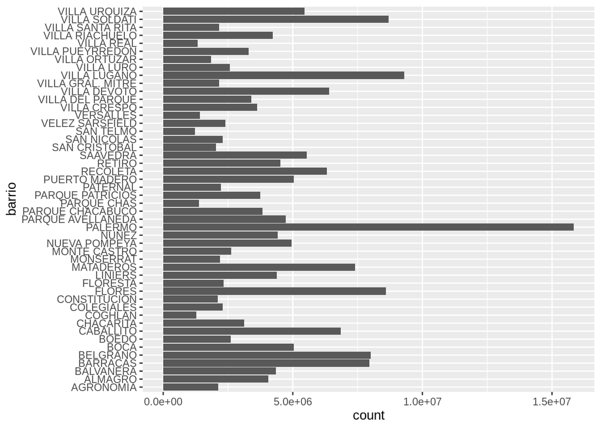

```r
ggplot(barrios) +
  geom_bar(aes(x = barrio, weight = area)) +
             coord_flip()
```

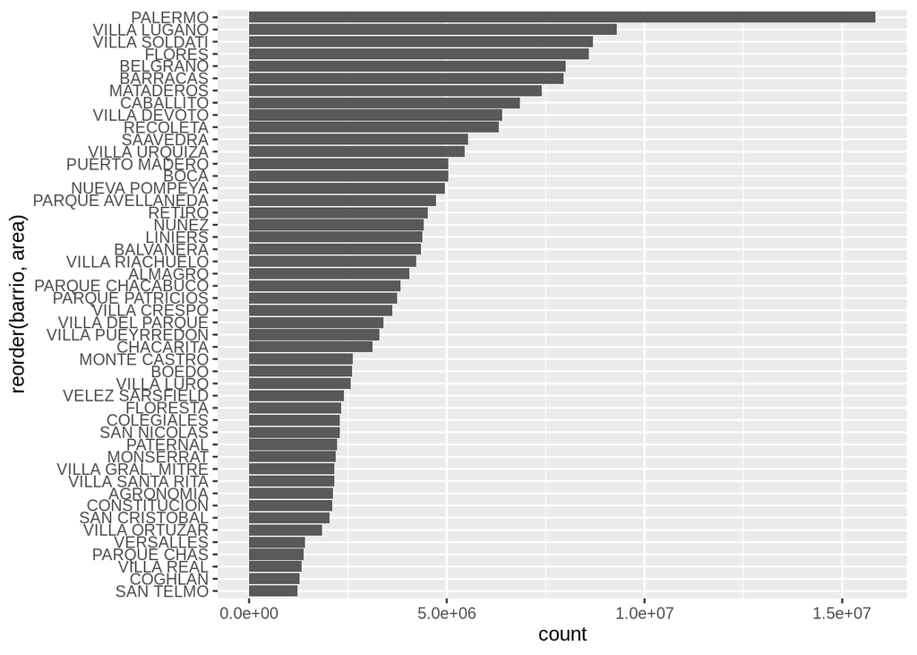

```r
ggplot(barrios %>% select(barrio, area)) +
  geom_bar(aes(x = reorder(barrio, area), weight = area)) +
  coord_flip()
```

#### Instalar y usar *sf* puede requerir más trabajo que los otros paquetes que vimos.

```r
# install.packages("sf")
library(sf)
barrios2 <- st_read("datos/barrios.csv")
```

### Como *comuna* es del tipo *caracter* lo ordena alfabeticamente…

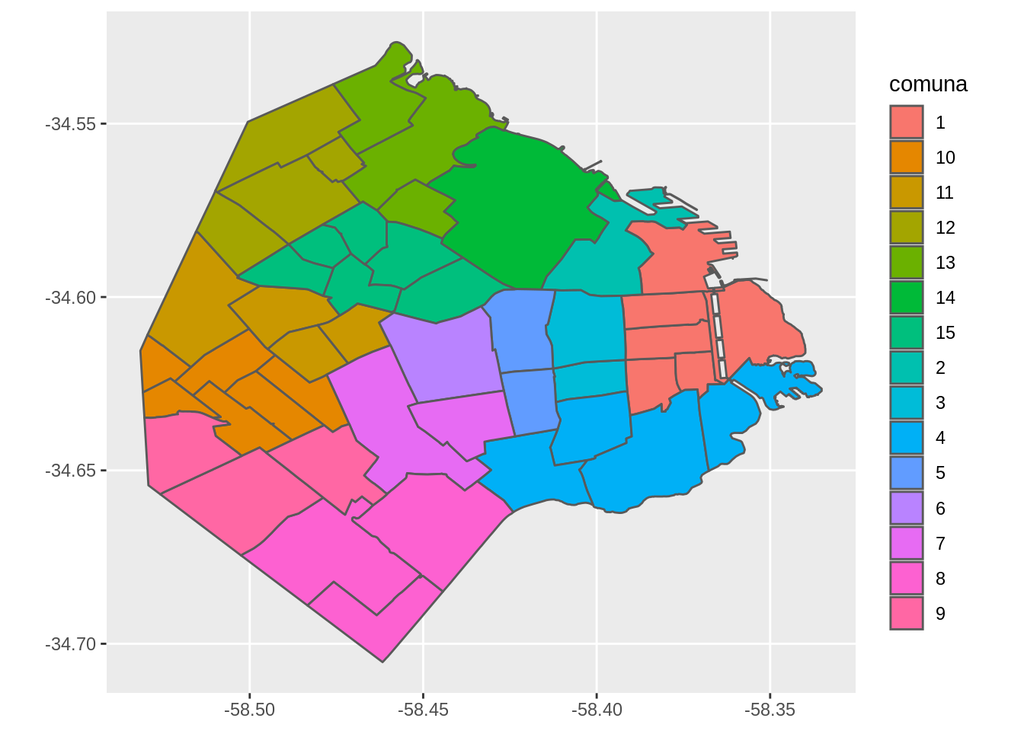

```r
ggplot(barrios2) +
  geom_sf(aes(fill=comuna))
```

### Si lo ponemos *numérico* lo ordena mejor, pero lo mustra como una variable continua, no *categórica* que es lo que corresponde.

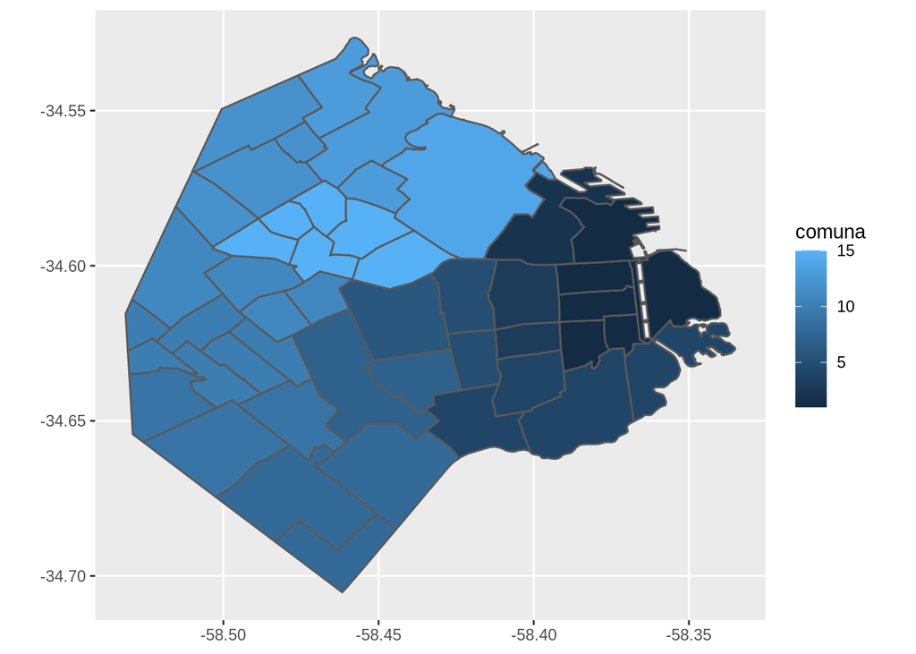

```r
barrios2$comuna <- as.numeric(barrios2$comuna)

ggplot(barrios2) +
  geom_sf(aes(fill=comuna))
```

### Para estos casos, variables categóricas, lo correcto es usar un tipo de R especial.

### Los *factores*

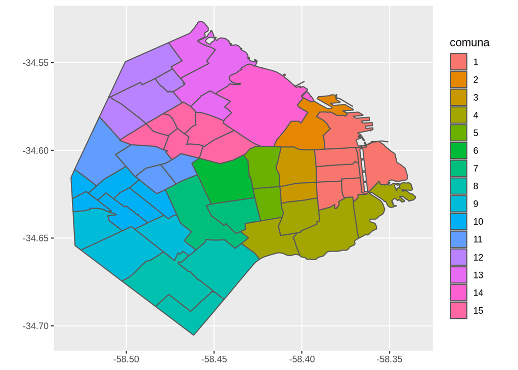

```r
barrios2$comuna <- factor(barrios2$comuna, levels = c("1", "2", "3", "4", "5", "6", "7", "8","9","10","11","12","13","14","15"))

ggplot(barrios2) +
  geom_sf(aes(fill=comuna))
```

### Bibliografia:

#### [Cheat Sheet *dplyr*](https://dplyr.tidyverse.org/index.html#cheat-sheet)

clase01.R